# Descripción del proyecto

## Análisis

### Media Movil

A continuación procederéa hacer un analisis rápido, evaluando la media movil para un rango de 1 dia (24 horas) en un periodo de dos meses (Marzo-Abril)

```python
data['rolling_mean'] = data.rolling(24).mean()
```

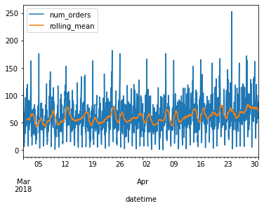

```python
data['2018-03':'2018-04'].plot()
```

En el gráfico anteriores(linea naranja), vemos ciertos picos que se repiten en el tiempo, los cuales representan claramente un patron. Analizaremos mas a fondo esto en el siguiente punto.

### Tendencias y estacionalidad

```python
def estacionalidad(inicio,fin):
    decomposed = seasonal_decompose(data[inicio:]['num_orders'])
    #decomposed.seasonal['2018-03-01':'2018-03-02'].plot()

    plt.figure(figsize=(10, 8))
    plt.subplot(311)
    # Para mostrar el gráfico de manera correcta, especifica su
    # eje ax igual a plt.gca() (gca = obtener el eje actual)
    decomposed.trend.plot(ax=plt.gca())
    plt.title('Trend')
    plt.subplot(312)
    # < escribe tu código aquí >
    decomposed.seasonal.plot(ax=plt.gca())
    plt.title('Seasonality')
    plt.subplot(313)
    # < escribe tu código aquí >
    decomposed.resid.plot(ax=plt.gca())
    plt.title('Residuals')
    plt.tight_layout()
```

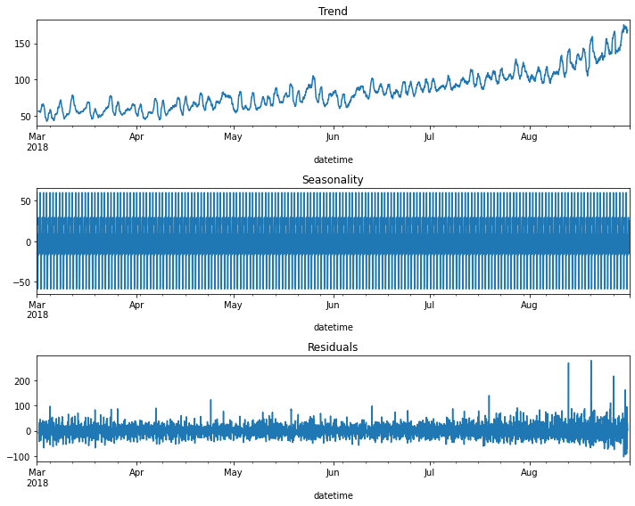

```python
estacionalidad('2018-03-01','2018-03-31')
```

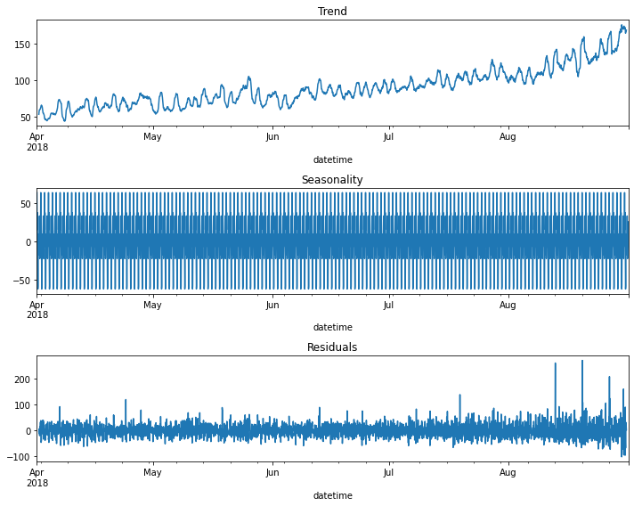

```python
estacionalidad('2018-04-01','2018-04-30')
```

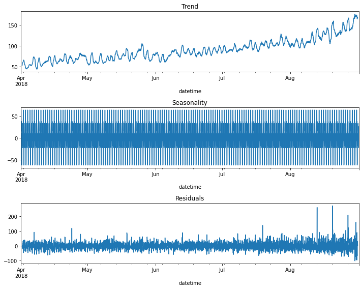

```python
estacionalidad('2018-04-01','2018-04-07')
```

## Formación

En base al analisis anterior, prepararé la data de entrenamiento, **enriqueciendo el dataset original**, agregando columnas que registren la hora, el día, el día de la semana y el mes. Además agregaré una columna adicional que muestre la media movil (tendencia) y algunas columnas de desfase (lag), para que el modelo tenga información (contexto) del comportamiento pasado antes de predecir. Todo esto lo implementaré en una función para poder probar con distintos valores de media movil y numero de columnas de lag.

```python
def crear_caracteristicas(data, max_lag, rolling_mean_size):
    data['month'] = data.index.month
    data['day'] = data.index.day
    data['hour'] = data.index.hour
    data['dayofweek'] = data.index.dayofweek

    data['rolling_mean'] = data['num_orders'].shift().rolling(rolling_mean_size).mean()

    for lag in range(1, max_lag + 1):
        data['lag_{}'.format(lag)] = data['num_orders'].shift(lag)
```

```python
#Probamos nuestra función para un valor 4 columnas de lag (valores anteriores) y una media movil de 4.
crear_caracteristicas(data, 4, 4)
data.head(30)
```

| datetime | num_orders | rolling_mean | month | day | hour | dayofweek | lag_1 | lag_2 | lag_3 | lag_4 |
| --- | --- | --- | --- | --- | --- | --- | --- | --- | --- | --- |
| 2018-03-01 00:00:00 | 124 | NaN | 3 | 1 | 0 | 3 | NaN | NaN | NaN | NaN |
| 2018-03-01 01:00:00 | 85 | NaN | 3 | 1 | 1 | 3 | 124.0 | NaN | NaN | NaN |
| 2018-03-01 02:00:00 | 71 | NaN | 3 | 1 | 2 | 3 | 85.0 | 124.0 | NaN | NaN |
| 2018-03-01 03:00:00 | 66 | NaN | 3 | 1 | 3 | 3 | 71.0 | 85.0 | 124.0 | NaN |
| 2018-03-01 04:00:00 | 43 | 86.50 | 3 | 1 | 4 | 3 | 66.0 | 71.0 | 85.0 | 124.0 |
| 2018-03-01 05:00:00 | 6 | 66.25 | 3 | 1 | 5 | 3 | 43.0 | 66.0 | 71.0 | 85.0 |
| 2018-03-01 06:00:00 | 12 | 46.50 | 3 | 1 | 6 | 3 | 6.0 | 43.0 | 66.0 | 71.0 |
| 2018-03-01 07:00:00 | 15 | 31.75 | 3 | 1 | 7 | 3 | 12.0 | 6.0 | 43.0 | 66.0 |
| 2018-03-01 08:00:00 | 34 | 19.00 | 3 | 1 | 8 | 3 | 15.0 | 12.0 | 6.0 | 43.0 |
| 2018-03-01 09:00:00 | 69 | 16.75 | 3 | 1 | 9 | 3 | 34.0 | 15.0 | 12.0 | 6.0 |
| 2018-03-01 10:00:00 | 64 | 32.50 | 3 | 1 | 10 | 3 | 69.0 | 34.0 | 15.0 | 12.0 |
| 2018-03-01 11:00:00 | 96 | 45.50 | 3 | 1 | 11 | 3 | 64.0 | 69.0 | 34.0 | 15.0 |
| 2018-03-01 12:00:00 | 30 | 65.75 | 3 | 1 | 12 | 3 | 96.0 | 64.0 | 69.0 | 34.0 |
| 2018-03-01 13:00:00 | 32 | 64.75 | 3 | 1 | 13 | 3 | 30.0 | 96.0 | 64.0 | 69.0 |
| 2018-03-01 14:00:00 | 48 | 55.50 | 3 | 1 | 14 | 3 | 32.0 | 30.0 | 96.0 | 64.0 |
| 2018-03-01 15:00:00 | 66 | 51.50 | 3 | 1 | 15 | 3 | 48.0 | 32.0 | 30.0 | 96.0 |
| 2018-03-01 16:00:00 | 43 | 44.00 | 3 | 1 | 16 | 3 | 66.0 | 48.0 | 32.0 | 30.0 |
| 2018-03-01 17:00:00 | 44 | 47.25 | 3 | 1 | 17 | 3 | 43.0 | 66.0 | 48.0 | 32.0 |
| 2018-03-01 18:00:00 | 73 | 50.25 | 3 | 1 | 18 | 3 | 44.0 | 43.0 | 66.0 | 48.0 |
| 2018-03-01 19:00:00 | 45 | 56.50 | 3 | 1 | 19 | 3 | 73.0 | 44.0 | 43.0 | 66.0 |
| 2018-03-01 20:00:00 | 61 | 51.25 | 3 | 1 | 20 | 3 | 45.0 | 73.0 | 44.0 | 43.0 |
| 2018-03-01 21:00:00 | 66 | 55.75 | 3 | 1 | 21 | 3 | 61.0 | 45.0 | 73.0 | 44.0 |
| 2018-03-01 22:00:00 | 113 | 61.25 | 3 | 1 | 22 | 3 | 66.0 | 61.0 | 45.0 | 73.0 |
| 2018-03-01 23:00:00 | 58 | 71.25 | 3 | 1 | 23 | 3 | 113.0 | 66.0 | 61.0 | 45.0 |
| 2018-03-02 00:00:00 | 90 | 74.50 | 3 | 2 | 0 | 4 | 58.0 | 113.0 | 66.0 | 61.0 |
| 2018-03-02 01:00:00 | 120 | 81.75 | 3 | 2 | 1 | 4 | 90.0 | 58.0 | 113.0 | 66.0 |
| 2018-03-02 02:00:00 | 75 | 95.25 | 3 | 2 | 2 | 4 | 120.0 | 90.0 | 58.0 | 113.0 |
| 2018-03-02 03:00:00 | 64 | 85.75 | 3 | 2 | 3 | 4 | 75.0 | 120.0 | 90.0 | 58.0 |
| 2018-03-02 04:00:00 | 20 | 87.25 | 3 | 2 | 4 | 4 | 64.0 | 75.0 | 120.0 | 90.0 |
| 2018-03-02 05:00:00 | 11 | 69.75 | 3 | 2 | 5 | 4 | 20.0 | 64.0 | 75.0 | 120.0 |

La función funciona correctamente.

## Entrenamiento y pruebas

Finalmente, entrenamos nuestros modelos(Arbol de decisión, Bosques Aleatorios, Regresión Lineal, LightGBM) con la data enriquecida en el punto anterior y nos quedamos con el de mejor desempeño. Para evaluar esto, usaré la metrica RMSE (Raiz del Error Cuadratico Medio).

*Nota: Los modelos serán entrenados inicialmente con hiperparametros definidos por mi para obtener una visión general del desempeño de cada modelo y luego (de ser necesario), optimizo el mejor modelo buscando mejores hiperparametros usando GridSearchCV.*

### Definimos nuestro set de entrenamiento y validación

```python
#Apartamos un 10% de los datos para la prueba de desempeño
train, test = train_test_split(data, shuffle=False, test_size=0.1)
train = train.dropna()

#Objetivo y caracteristicas (entrenamiento)
features_train=train.drop('num_orders', axis=1)
target_train=train['num_orders']

#Objetivo y caracteristicas (validación)
features_valid=test.drop('num_orders', axis=1)
target_valid=test['num_orders']
```

### Entrenamientos preliminares

#### Modelo Arbol de decisión

```python
#Iniciamos el modelo
model_tree = DecisionTreeRegressor(max_depth=15)
#Entrenamos
model_tree.fit(features_train,target_train)
#Evaluamos
prediction=model_tree.predict(features_valid)
rmse_tree= mean_squared_error(target_valid,prediction,squared=False)
print_mejorado(f"RMSE(RECM) para el modelo Arbol de decisión: {rmse_tree:.2f}",20)
```

RMSE(RECM) para el modelo Arbol de decisión: 55.32

#### Modelo Bosques Aleatorios

```python
#Iniciamos el modelo
model_forest = RandomForestRegressor(max_depth=10,n_estimators=10)
#Entrenamos
model_forest.fit(features_train,target_train)
#Evaluamos
prediction=model_forest.predict(features_valid)
rmse_forest= mean_squared_error(target_valid,prediction,squared=False)
print_mejorado(f"RMSE(RECM) para el modelo Bosques Aleatorios: {rmse_forest:.2f}",20)
```

RMSE(RECM) para el modelo Bosques Aleatorios: 51.78

#### Modelo de Regresión Lineal

```python
#Iniciamos el modelo
model_linear = LinearRegression(fit_intercept=True, normalize=False)
#Entrenamos
model_linear.fit(features_train,target_train)
#Evaluamos
prediction=model_linear.predict(features_valid)
rmse_linear= mean_squared_error(target_valid,prediction,squared=False)
print_mejorado(f"RMSE(RECM) para el modelo de Regresión Lineal: {rmse_linear:.2f}",20)
```

RMSE(RECM) para el modelo de Regresión Lineal: 52.57

#### Modelo de potenciación del grandiente (LightGBM)

```python
#Iniciamos el modelo
model_lgb = lgb.LGBMRegressor(boosting_type='gbdt', objective='regression', num_leaves=31,learning_rate= 0.25, n_estimators=200)
#Entrenamos
model_lgb.fit(features_train,target_train)
#Evaluamos
prediction=model_lgb.predict(features_valid)
rmse_lgb= mean_squared_error(target_valid,prediction,squared=False)
print_mejorado(f"RMSE(RECM) para el modelo de LightGBM: {rmse_lgb:.2f}",20)
```

RMSE(RECM) para el modelo de LightGBM: 45.77

### Busqueda de hiperparametros idoneos para cada modelo con GridSearchCV

En el punto anterior, vimos que el desempeño del modelo LightGBM con los hiperparametros definidos cumple con lo requerido y podriamos quedarnos con este modelo. Sin embargo, entrenaremos los modelos nuevamente, esta vez usando GridSearchCV para buscar los mejores hiperparametros.

#### Definimos el score RMSE a optimizar con GridSeach

```python
def rmse(y_true, y_pred):
    return np.sqrt(mean_squared_error(y_true, y_pred))

rmse_scorer = make_scorer(rmse, greater_is_better=False)
```

#### Modelo Arbol de decisión (GridSearchCV)

```python
model_tree = DecisionTreeRegressor()
#Hiperparametros a probar
param_grid_tree = {'max_depth': [1,2,3,4,5,6,7,8,9,10]}
#Buscamos los mejores hiperparametros para DecisionTreeRegressor con 3 grupos de validacion (cv=3)
grid_search_tree = GridSearchCV(model_tree, param_grid_tree,scoring=rmse_scorer, cv=3)
grid_search_tree.fit(features_train, target_train)
best_params_tree = grid_search_tree.best_params_
best_score_tree = grid_search_tree.best_score_

print_mejorado(f"Mejores hiperparámetros(tree): {best_params_tree}",20)
print_mejorado(f"Mejor puntuación GridSearchCV(tree): {abs(best_score_tree):.3f}", 20)
```

Mejores hiperparámetros(tree): {'max_depth': 7}

Mejor puntuación GridSearchCV(tree): 31.541

```python
#Evaluamos con dataset de validación (10% de los datos)
prediction=grid_search_tree.predict(features_valid)
rmse_tree2= mean_squared_error(target_valid,prediction,squared=False)
print_mejorado(f"RMSE(RECM) para el modelo Arbol de decisión: {rmse_tree2:.2f}",20)
```

RMSE(RECM) para el modelo Arbol de decisión: 53.83

#### Modelo Bosques Aleatorios (GridSearchCV)

```python
model_forest = RandomForestRegressor()
#Hiperparametros a probar
param_grid_forest = {'max_depth': [1,2,3,4,5,6,7,8,9,10],'n_estimators': [1,2,3,4,5,6,7,8,9,10]}

#Buscamos los mejores hiperparametros para RandomForestRegressor con 3 grupos de validacion (cv=3)
grid_search_forest = GridSearchCV(model_forest, param_grid_forest,scoring=rmse_scorer, cv=3)
grid_search_forest.fit(features_train, target_train)
best_params_forest = grid_search_forest.best_params_
best_score_forest = grid_search_forest.best_score_

print_mejorado(f"Mejores hiperparámetros(forest): {best_params_forest}",20)
print_mejorado(f"Mejor puntuación GridSearchCV(forest): {abs(best_score_forest):.3f}", 20)
```

Mejores hiperparámetros(forest): {'max_depth': 10, 'n_estimators': 5}

Mejor puntuación GridSearchCV(forest): 28.097

```python
#Evaluamos con dataset de validación (10% de los datos)
prediction=grid_search_forest.predict(features_valid)
rmse_forest2= mean_squared_error(target_valid,prediction,squared=False)
print_mejorado(f"RMSE(RECM) para el modelo Bosque Aleatorio: {rmse_forest2:.2f}",20)
```

RMSE(RECM) para el modelo Bosque Aleatorio: 52.01

#### Modelo de Regresion Lineal (GridSearchCV)

```python
model_linear = LinearRegression(fit_intercept=True, normalize=False)
#Hiperparametros a probar
param_grid_linear = {'fit_intercept': [True,False], 'normalize':[True,False]}

#Buscamos los mejores hiperparametros para LinearRegression con 3 grupos de validacion (cv=3)
grid_search_linear = GridSearchCV(model_linear, param_grid_linear,scoring=rmse_scorer, cv=3)
grid_search_linear.fit(features_train, target_train)
best_params_linear = grid_search_linear.best_params_
best_score_linear = grid_search_linear.best_score_

print_mejorado(f"Mejores hiperparámetros(linear): {best_params_linear}",20)
print_mejorado(f"Mejor puntuación GridSearchCV(linear): {abs(best_score_linear):.3f}", 20)
```

Mejores hiperparámetros(linear): {'fit_intercept': False, 'normalize': True}

Mejor puntuación GridSearchCV(linear): 30.763

```python
#Evaluamos con dataset de validación (10% de los datos)
prediction=grid_search_linear.predict(features_valid)
rmse_linear2= mean_squared_error(target_valid,prediction,squared=False)
print_mejorado(f"RMSE(RECM) para el modelo de Regresión Lineal: {rmse_linear2:.2f}",20)
```

RMSE(RECM) para el modelo de Regresión Lineal: 52.13

#### Modelo LightGBM (GridSearchCV)

```python
model_lgb = lgb.LGBMRegressor(boosting_type='gbdt', objective='regression', n_estimators=200)
#Hiperparametros a probar
param_grid_lgb = {'num_leaves': [10,20,30,40,50],'learning_rate': [0.25,0.5,0.75,1]}

#Buscamos los mejores hiperparametros para LightGBM con 3 grupos de validacion (cv=3)
grid_search_lgb = GridSearchCV(model_lgb, param_grid_lgb,scoring=rmse_scorer, cv=3)
grid_search_lgb.fit(features_train, target_train)
best_params_lgb = grid_search_lgb.best_params_
best_score_lgb = grid_search_lgb.best_score_

print_mejorado(f"Mejores hiperparámetros(LightGBM): {best_params_lgb}",20)
print_mejorado(f"Mejor puntuación GridSearchCV(LightGBM): {abs(best_score_lgb):.3f}", 20)
```

Mejores hiperparámetros(LightGBM): {'learning_rate': 0.25, 'num_leaves': 10}

Mejor puntuación GridSearchCV(LightGBM): 26.497

```python
#Evaluamos con dataset de validación (10% de los datos)
prediction=grid_search_lgb.predict(features_valid)
rmse_lgb2= mean_squared_error(target_valid,prediction,squared=False)
print_mejorado(f"RMSE(RECM) para el modelo LightGBM: {rmse_lgb2:.2f}",20)
```

RMSE(RECM) para el modelo LightGBM: 43.85

## Comparación de cada modelo

```python
resumen = {
    'Modelo': ['Arbol de decisión', 'Bosque Aleatorio', 'Regresión Lineal','LightGBM'],
    'Desempeño (RMSE)':[rmse_tree,rmse_forest,rmse_linear,rmse_lgb],
    'Desempeño tras GridSearch (RMSE)':[rmse_tree2,rmse_forest2,rmse_linear2,rmse_lgb2]
}
#Utilizo round para aproximar a un solo digito
resumen = pd.DataFrame(resumen).round(1)
resumen
```

|  | Modelo | Desempeño (RMSE) | Desempeño tras GridSearch (RMSE) |
| --- | --- | --- | --- |
| 0 | Arbol de decisión | 55.3 | 53.8 |
| 1 | Bosque Aleatorio | 51.8 | 52.0 |
| 2 | Regresión Lineal | 52.6 | 52.1 |
| 3 | LightGBM | 45.8 | 43.8 |

Como se puede apreciar en la tabla anterior, tras usar GridSearchCV, en la mayoría de los modelos el desempeño mejoró, obteniendo 2 puntos mas en el modelo de mayor desempeño (LightGBM). Cabe destacar que el desempeño en el modelo de Bosque aleatorio disminuyo tras usar GridSearchCV y sospecho que este comportamiento puede ser debido a que ese modelo esta muy sobreajustado y al probarlo con nueva data, su desempeño no es tan confiable.

## Conclusión

Finalmente, tras la busqueda de los mejores hiperparamentros, el modelo LightGBM con `num_leaves=10,learning_rate= 0.25, n_estimators=200` cumplió con los requerimientos del solicitante(RMSE<48 con un RMSE de 43.8.